# Introduction to R Programming

# 1 Objectives

This lesson covers some basic exposure to R functions and data objects.

# 2 Materials

View the slides for this section [here](https://mjfrigaard.github.io/csuc-data-journalism/slides.html).

View the exercises for this section [here](https://mjfrigaard.github.io/csuc-data-journalism/lessons-exercises.html).

# 3 R Syntax

Two major elements in R programming: functions and objects.

## 3.1 Functions & Objects

- **Functions** perform operations (calculate a mean, build a table, create a graph, etc.)
- **Objects** hold information (a collection of numbers, dates, words, models results, etc.)

# 4 Vectors

Vectors are the fundamental data type in R. Most R functions are ‘vectorized’, meaning they’re optimized to work on vectors.

## 4.1 Atomic vectors

The “atomic” in atomic vectors means, “*of or forming a single irreducible unit or component in a larger system.*”

### 4.1.1 Logical

Logical vectors are handy because when we add them together, and the total number tells us how many `TRUE` values there are.

```r
vec_logical <- c(TRUE, FALSE)
vec_logical
```

```
#> [1]  TRUE FALSE
```

### 4.1.2 Integer

Integer vectors are created with a number and capital letter `L`

```r
vec_integer <- c(1L, 10L, 100L)
vec_integer
```

```
#> [1]   1  10 100
```

### 4.1.3 Double

Double vectors can be entered as decimals

```r
vec_double <- c(0.1, 1.0, 10.01)
vec_double
```

```
#> [1]  0.10  1.00 10.01
```

### 4.1.4 Character

Note that character vectors need to be in quotes.

```r
vec_character <- c("A", "B", "C")
vec_character
```

```
#> [1] "A" "B" "C"
```

## 4.2 Evaluating vectors

**Store and explore** - create an object, perform an operation on the object, store the results, then explore the contents with another function.

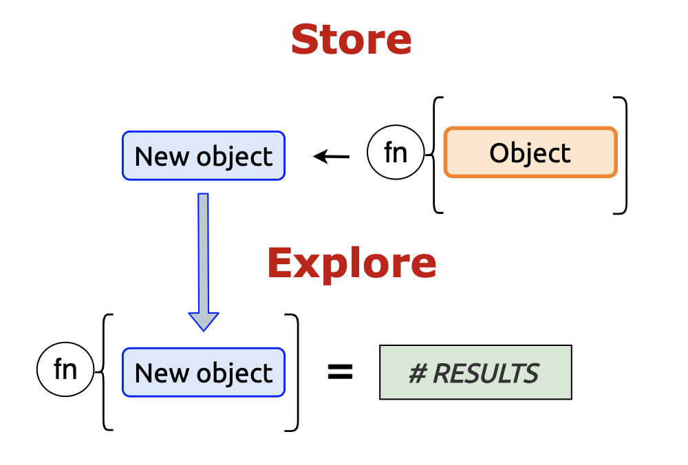

### 4.2.1 `typeof()`

Explore all vectors with `typeof()`

```r
typeof(vec_integer)
```

```
#> [1] "integer"
```

### 4.2.2 `is.integer()`

Integers have no decimals.

```r
is.integer(vec_integer)
```

```
#> [1] TRUE
```

### 4.2.3 `is.numeric()`

Evaluate numeric vectors with `is.numeric()`

```r
is.numeric(vec_double)
```

```
#> [1] TRUE
```

### 4.2.4 `is.logical()`

`is.logical()` to check vectors that are logical.

```r
is.logical(vec_logical)
```

```
#> [1] TRUE
```

Recall that you can sum logical vectors.

```r
TRUE + TRUE + FALSE + TRUE
```

```
#> [1] 3
```

Great for subsetting too.

```r
vec_integer > 5
```

```
#> [1] FALSE  TRUE  TRUE
```

### 4.2.5 `is.character()`

Check character vectors with `is.character()`

```r
is.character(vec_character)
```

```
#> [1] TRUE
```

## 4.3 Vectorized

R is often referred to as a “vector-oriented”, “vectorized”, or “element-wise” language because of the way it deals with vectors. We will show an example of this behavior below:

### 4.3.1 Create sequence of values

THe code below creates a sequence of ten values between `1.5` and `10.5`.

```r
vec_seq_01 <- 1.5:10.5
length(vec_seq_01)
```

```
#> [1] 10
```

```r
vec_seq_01
```

```
#>  [1]  1.5  2.5  3.5  4.5  5.5  6.5  7.5  8.5  9.5 10.5
```

### 4.3.2 Vector operation by position

Now we create `vec_seq_02`, which has a sequence of ten values between `0.2` and `2.0`.

```r
vec_seq_02 <- c(0.2, 0.4, 0.6, 0.8, 1.0,
                1.2, 1.4, 1.6, 1.8, 2.0)
vec_seq_02
```

```
#>  [1] 0.2 0.4 0.6 0.8 1.0 1.2 1.4 1.6 1.8 2.0
```

Now we subtract `vec_seq_02` from `vec_seq_01`:

```r
vec_seq_01 - vec_seq_02
```

```
#>  [1] 1.3 2.1 2.9 3.7 4.5 5.3 6.1 6.9 7.7 8.5
```

The result is a vector that’s the subtraction of the first element of `vec_seq_02` from the first element of `vec_seq_01`, and so on…

```r
vec_seq_01[1] - vec_seq_02[1]
```

```
#> [1] 1.3
```

```r
vec_seq_01[2] - vec_seq_02[2]
```

```
#> [1] 2.1
```

```r
vec_seq_01[3] - vec_seq_02[3]
```

```
#> [1] 2.9
```

### 4.3.3 unequal lengths

Both `vec_seq_01` and `vec_seq_02` have equal lengths. What happens when we apply vectorized operations to objects of unequal length? Well, R attempts to recycle the operations. We will demonstrate this by creating `vec_seq_03`, which only has three numbers in it:

```r
vec_seq_03 <- vec_seq_02[1:3]
vec_seq_03
```

```
#> [1] 0.2 0.4 0.6
```

```r
vec_seq_01 - vec_seq_03
```

```
#>  [1]  1.3  2.1  2.9  4.3  5.1  5.9  7.3  8.1  8.9 10.3
```

That’s why the first three numbers of `vec_seq_01 - vec_seq_03` look identical to `vec_seq_01 - vec_seq_02`:

```r
# compare first three elements
vec_seq_01[1:3] - vec_seq_02[1:3]
```

```
#> [1] 1.3 2.1 2.9
```

```r
# compare first three elements
vec_seq_01[1:3] - vec_seq_03[1:3]
```

```
#> [1] 1.3 2.1 2.9
```

But when R goes looking elements at position `vec_seq_03[4]`, it finds nothing (`NA`):

```r
vec_seq_03[4]
```

```
#> [1] NA
```

So it recycles at the beginning of the vector again. Look at the code below to see how this behavior creates the values in `vec_seq_01 - vec_seq_03`.

```r
vec_seq_01 - vec_seq_03
```

```
#>  [1]  1.3  2.1  2.9  4.3  5.1  5.9  7.3  8.1  8.9 10.3
```

```r
vec_seq_01[1:3] - vec_seq_03[1:3]
```

```
#> [1] 1.3 2.1 2.9
```

```r
vec_seq_01[4:6] - vec_seq_03[1:3]
```

```
#> [1] 4.3 5.1 5.9
```

```r
vec_seq_01[7:9] - vec_seq_03[1:3]
```

```
#> [1] 7.3 8.1 8.9
```

```r
vec_seq_01[10] - vec_seq_03[1]
```

```
#> [1] 10.3
```

If `vec_seq_01` had a length that was a multiple of `vec_seq_03`, R would’ve still performed recycling (but without an error message).

```r
vec_seq_04 <- vec_seq_02[1:5]
vec_seq_01 - vec_seq_04
```

```
#>  [1] 1.3 2.1 2.9 3.7 4.5 6.3 7.1 7.9 8.7 9.5
```

## 4.4 S3 vectors

S3 vector objects are factors, dates, date-times, durations.

### 4.4.1 Factors

Factors are categorical vectors with a given set of responses.

```r
vec_factor <- factor(x = c("low", "medium", "high"))
vec_factor
```

```
#> [1] low    medium high
#> Levels: high low medium
```

```r
# Not character variables!
typeof(vec_factor)
```

```
#> [1] "integer"
```

We can manually assign the order of factor levels with the `levels` argument in `factor()`.

```r
vec_factor <- factor(x = c("medium", "high", "low"),
                     levels = c("low", "medium", "high"))
# check with:
levels(vec_factor)
```

```
#> [1] "low"    "medium" "high"
```

```r
unclass(vec_factor)
```

```
#> [1] 2 3 1
#> attr(,"levels")
#> [1] "low"    "medium" "high"
```

### 4.4.2 Dates

R also comes with a few functions for creating dates (`Sys.Date()` and `Sys.time()`).

```r
vec_date <- c(Sys.Date(), Sys.Date() + 1, Sys.Date() + 2)
vec_date
```

```
#> [1] "2021-11-20" "2021-11-21" "2021-11-22"
```

Dates are stored as `double` vectors with a class attribute set to `"Date"`.

```r
is.double(vec_date)
```

```
#> [1] TRUE
```

```r
attributes(vec_date)
```

```
#> $class
#> [1] "Date"
```

The number for each date is accessible using the `unclass()` function:

```r
unclass(vec_date)
```

```
#> [1] 18951 18952 18953
```

The number are related to the [UNIX Epoch time](https://en.wikipedia.org/wiki/Unix_time), which is January 1, 1970 (00:00:00 UTC).

The Unix epoch serves as a point in time in which the computer can calculate dates *from*. The actual date and time is arbitrary, but without a fixed point in time, there’s no way to quantify or measure a ‘date.’

### 4.4.3 Date-times

Date-times contain a bit more information than dates. In R, the `POSIX` date format is the time since January 1, 1970 (in the UTC time zone), measured to the nearest second.

`POSIXct` represents this as a numeric vector, and `POSIXlt` is list of named date/time vectors.

```r
vec_datetime_ct <- as.POSIXct(vec_date)
vec_datetime_ct
```

```
#> [1] "2021-11-19 17:00:00 MST" "2021-11-20 17:00:00 MST"
#> [3] "2021-11-21 17:00:00 MST"
```

```r
typeof(vec_datetime_ct)
```

```
#> [1] "double"
```

```r
vec_datetime_lt <- as.POSIXlt(vec_date)
vec_datetime_lt
```

```
#> [1] "2021-11-20 UTC" "2021-11-21 UTC" "2021-11-22 UTC"
```

```r
typeof(vec_datetime_lt)
```

```
#> [1] "list"
```

For `vec_datetime_ct`, we can access the epoch time with `unclass()`

```r
unclass(vec_datetime_ct)
```

```
#> [1] 1637366400 1637452800 1637539200
```

In `vec_datetime_lt`, each date/time measurement is in a named vector:

```r
unclass(vec_datetime_lt)
```

```
#> $sec
#> [1] 0 0 0
#>
#> $min
#> [1] 0 0 0
#>
#> $hour
#> [1] 0 0 0
#>
#> $mday
#> [1] 20 21 22
#>
#> $mon
#> [1] 10 10 10
#>
#> $year
#> [1] 121 121 121
#>
#> $wday
#> [1] 6 0 1
#>
#> $yday
#> [1] 323 324 325
#>
#> $isdst
#> [1] 0 0 0
#>
#> attr(,"tzone")
#> [1] "UTC"
```

For the `"Date"` class, the number represents the number of days, and for the `"POSIX` classes, this represents the number of seconds (to the nearest second) since the epoch.

The `"POSIXct"`/`"POSIXlt"` classes also both contain a time-zone (explore your system’s time-zone with `Sys.timezone(location = TRUE)`).

### 4.4.4 Durations (difftime)

We need two times to be able to calculate the difftime, but the output is fairly clear.

```r
time_01 <- Sys.Date()
time_02 <- Sys.Date() + 10
vec_difftime <- difftime(time_01, time_02, units = "days")
vec_difftime
```

```
#> Time difference of -10 days
```

These have `class` and `units` attributes.

```r
attributes(vec_difftime)
```

```
#> $class
#> [1] "difftime"
#>
#> $units
#> [1] "days"
```

# 5 Multidimensional objects

In the next sections we’ll cover matrices and arrays, two of R’s multidimensional objects.

## 5.1 Matrices

These are two-dimensional objects. We can create with `matrix()`.

### 5.1.1 Create matrices

We can make a matrix using our existing vectors.

```r
mat_data <- matrix(data = c(vec_double, vec_integer),
                   nrow = 3, ncol = 2, byrow = FALSE)
mat_data
```

```
#>       [,1] [,2]
#> [1,]  0.10    1
#> [2,]  1.00   10
#> [3,] 10.01  100
```

### 5.1.2 Check dimensions

We can check the dimensions of `mat_data` with `dim()`.

```r
dim(mat_data)
```

```
#> [1] 3 2
```

### 5.1.3 Matrix positions

We can subset using position.

```r
mat_data[2, 2]
```

```
#> [1] 10
```

## 5.2 Arrays

Arrays are like matrices, but with more dimensions.

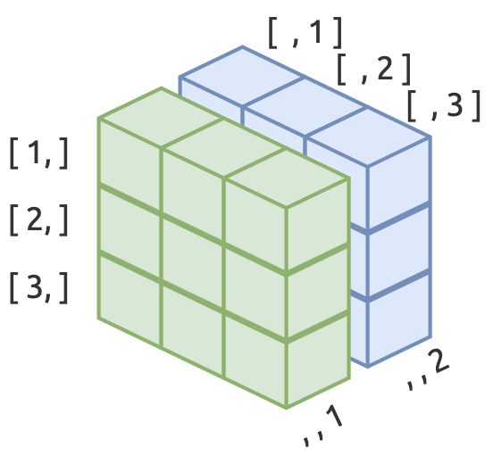

### 5.2.1 Create an array

Arrays need three dimensions in the `dim` argument.

```r
dat_array <- array(data = c(1, 2, 3, 4, 5, 6, 7, 8, 9, 10, 11, 12, 13,
                            14, 15, 16, 17, 18), dim = c(3, 3, 2))
dat_array
```

```
#> , , 1
#>
#>      [,1] [,2] [,3]
#> [1,]    1    4    7
#> [2,]    2    5    8
#> [3,]    3    6    9
#>
#> , , 2
#>
#>      [,1] [,2] [,3]
#> [1,]   10   13   16
#> [2,]   11   14   17
#> [3,]   12   15   18
```

### 5.2.2 Matrix vs. Array

Matrices are arrays, but arrays are not matrices.

```r
class(dat_array)
```

```
#> [1] "array"
```

```r
class(mat_data)
```

```
#> [1] "matrix" "array"
```

# 6 Rectangular data in R

If you’re importing spreadsheets, most of the work you’ll do in R will be with rectangular data objects (i.e. `data.frame`s and `tibble`s).

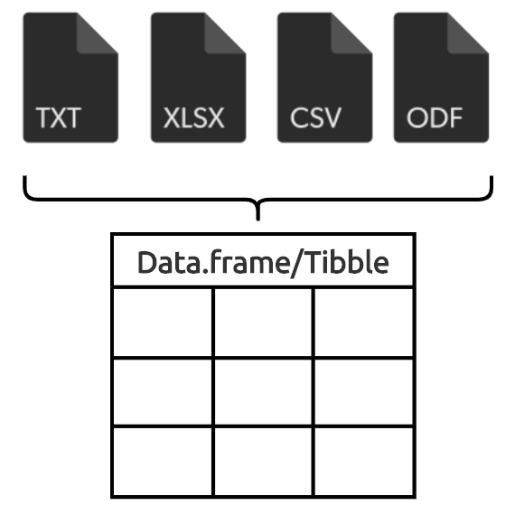

## 6.1 Data Frames

Rectangular data with rows and columns.

### 6.1.1 Create data frames

We will create a data frame below using `data.frame()`. When we create a data frame, the data are transposed (i.e. columns are written left-to-right).

```r
DataFrame <- data.frame(character = c("A", "B", "C"),
                        integer = c(0.1, 1.0, 10.01),
                        logical = c(TRUE, FALSE, TRUE),
                        stringsAsFactors = FALSE)
DataFrame
```

| character | integer | logical |
| --- | --- | --- |
| A | 0.10 | TRUE |
| B | 1.00 | FALSE |
| C | 10.01 | TRUE |

*NOTE: `stringsAsFactors = FALSE` is not required as of R version 4.0.0.*

### 6.1.2 Inspect `data.frame`s

Check the structure of the data.frame with `str()`

```r
str(DataFrame)
```

```
#> 'data.frame':    3 obs. of  3 variables:
#>  $ character: chr  "A" "B" "C"
#>  $ integer  : num  0.1 1 10
#>  $ logical  : logi  TRUE FALSE TRUE
```

## 6.2 Tibbles

These are special kinds of `data.frame`s (they print better to the console, and character vectors are never coerced into factors).

### 6.2.1 Create `tibble`s

Creating `tibble`s is *not* transposed.

```r
Tibble <- tibble::tribble(
       ~character, ~integer,  ~logical,
              "A",      0.1,      TRUE,
              "B",        1,     FALSE,
              "C",    10.01,      TRUE)
Tibble
```

| character | integer | logical |
| --- | --- | --- |
| A | 0.10 | TRUE |
| B | 1.00 | FALSE |
| C | 10.01 | TRUE |

### 6.2.2 Inspect `tibble`s

`tibbles` are S3 objects, with types `tbl_df`, `tbl`, *and* `data.frame`

```r
str(Tibble)
```

```
#> tibble [3 × 3] (S3: tbl_df/tbl/data.frame)
#>  $ character: chr [1:3] "A" "B" "C"
#>  $ integer  : num [1:3] 0.1 1 10
#>  $ logical  : logi [1:3] TRUE FALSE TRUE
```

# 7 The ‘catch-all’

Lists are unique objects in R because they are *recursive vectors*. We’ve pointed out that atomic vectors can’t be broken down into smaller components, but a list can store objects of multiple types (character, numeric, logical, etc.), `data.frame`s, `tibble`s, and even other lists.

## 7.1 Lists

Unlike `data.frame`s, `tibble`s (which require each vector to be of equal length), lists can store objects of different types *and* sizes.

### 7.1.1 Create lists

We can put all the objects we’ve created in `dat_list`.

```r
dat_list <- list("integer" = vec_integer,
                 "array" = dat_array,
                 "matrix data" = mat_data,
                 "data frame" = DataFrame,
                 "tibble" = Tibble)
dat_list
```

```
#> $integer
#> [1]   1  10 100
#>
#> $array
#> , , 1
#>
#>      [,1] [,2] [,3]
#> [1,]    1    4    7
#> [2,]    2    5    8
#> [3,]    3    6    9
#>
#> , , 2
#>
#>      [,1] [,2] [,3]
#> [1,]   10   13   16
#> [2,]   11   14   17
#> [3,]   12   15   18
#>
#>
#> $`matrix data`
#>       [,1] [,2]
#> [1,]  0.10    1
#> [2,]  1.00   10
#> [3,] 10.01  100
#>
#> $`data frame`
#>   character integer logical
#> 1         A    0.10    TRUE
#> 2         B    1.00   FALSE
#> 3         C   10.01    TRUE
#>
#> $tibble
#> # A tibble: 3 × 3
#>   character integer logical
#>   <chr>       <dbl> <lgl>
#> 1 A             0.1 TRUE
#> 2 B             1   FALSE
#> 3 C            10.0 TRUE
```

### 7.1.2 List attributes

And we can see all of these elements are stored (with the appropriate name).

```r
attributes(dat_list)
```

```
#> $names
#> [1] "integer"     "array"       "matrix data" "data frame"  "tibble"
```

Think of `data.frame`s and `tibble`s as special kinds of rectangular `lists`, made with different types of vectors, with each vector being of equal length.